# Google Data Analytics Capstone Project

Case Study 2: How Can a Wellness Technology Company Play It Smart?

Brandon Luong

2021-06-24

# 1 Introduction

As part of the Google Data Analytics Program, I am tasked with completing a Capstone case study. I have chosen to do this project in R because the dataset file size is too large to comfortably work in spreadsheets (Excel/Google Sheets). This project can be done in SQL, but R has many handy packages such as tidyverse for data cleaning and analysis.

I am part of the marketing analytics team at Bellabeat, a high-tech manufacturer of health-focused products for women. Bellabeat is a small successful company but has the potential for growth in the global smart device market. Urška Sršen believes that analyzing smart fitness data could help with this growth and unlock new opportunities for the company.

The Bellabeat Products:

- Bellabeat app: The Bellabeat app provides users with health data related to their activity, sleep, stress, menstrual cycle, and mindfulness habits. This data can help users better understand their current habits and make healthy decisions. The Bellabeat app connects to their line of smart wellness products.
- Leaf: Bellabeat’s classic wellness tracker can be worn as a bracelet, necklace, or clip. The Leaf tracker connects to the Bellabeat app to track activity, sleep, and stress.
- Time: This wellness watch combines the timeless look of a classic timepiece with smart technology to track user activity, sleep, and stress. The Time watch connects to the Bellabeat app to provide you with insights into your daily wellness.
- Spring: This is a water bottle that tracks daily water intake using smart technology to ensure that you are appropriately hydrated throughout the day. The Spring bottle connects to the Bellabeat app to track your hydration levels.

# 2 Ask

Primary stakeholders:

- Urška Sršen: Cofounder and Chief Creative Officer
- Sando Mur: Cofounder and key member of the Bellabeat executive team

Secondary stakeholders:

- Bellabeat marketing analytics team: A team of data analysts responsible for collecting, analyzing, and reporting data that helps guide Bellabeat’s marketing strategy.

Main questions to answer in this analysis:

1. What are some trends in smart device usage?
2. How could these trends apply to Bellabeat customers?
3. How could these trends help influence Bellabeat marketing strategy?

Main deliverables (ie. objectives) to report:

1. A clear summary of the business task
2. A description of all data sources used
3. Documentation of any cleaning or manipulation of data
4. A summary of your analysis
5. Supporting visualizations and key findings
6. Your top high-level content recommendations based on your analysis

**1. A clear summary of the business task:**

Analyze smart device usage data for trends and insights and apply the new-found knowledge to one Bellabeat product, presenting high-level recommendations for how these trends can improve Bellabeat’s marketing strategy.

# 3 Prepare

Dataset:

- [Kaggle Fitbit Fitness Tracker Data](https://www.kaggle.com/arashnic/fitbit), by Mobius

License:

- CC0: Public Domain

Storage:

- The data is originally stored in 18 csv files on Kaggle.
- It is then downloaded and stored locally on my computer for analysis.

## 3.1 Load libraries

```r
library(tidyverse) # General purpose data science package
library(janitor) # Data cleaning
library(lubridate) # Date parsing and cleaning
library(skimr) # Viewing
```

## 3.2 Import csv files

```r
# Per Day
daily_act <- read_csv('dailyActivity_merged.csv') # Use
daily_cal <- read_csv('dailyCalories_merged.csv')
daily_intense <- read_csv('dailyIntensities_merged.csv')
daily_steps <- read_csv('dailySteps_merged.csv')
daily_sleep <- read_csv('sleepDay_merged.csv') # Use
# Per Hour
hourly_cal <-read_csv('hourlyCalories_merged.csv')
hourly_intense <- read_csv('hourlyIntensities_merged.csv')
hourly_steps <- read_csv('hourlySteps_merged.csv')
# Per Minute
min_cal_narrow <- read_csv('minuteCaloriesNarrow_merged.csv')
min_cal_wide <- read_csv('minuteCaloriesWide_merged.csv')
min_intense_narrow <- read_csv('minuteIntensitiesNarrow_merged.csv')
min_intense_wide <- read_csv('minuteIntensitiesWide_merged.csv')
min_steps_narrow <- read_csv('minuteStepsNarrow_merged.csv')
min_steps_wide <- read_csv('minuteStepsWide_merged.csv')
min_sleep <- read_csv('minuteSleep_merged.csv')
min_met_narrow <- read_csv('minuteMETsNarrow_merged.csv')
# Per Second
sec_heartrate <- read_csv('heartrate_seconds_merged.csv')
# Other
weight_log <- read_csv('weightLogInfo_merged.csv')
```

Assumptions:

- The data seems to be broken up into daily, hourly, per minute, per second, and other categories.
- Because I want to analyze general trends, I may want to just focus on the daily files for trends over the course of the month.
- I may drop the hourly, per minute, and per second files as they may capture such a small time interval per observation that it may not be useful for my particular analysis.
- Some files may just be repeats of the same data but in different formats (eg. daily_cal vs hourly_cal, min_intense_narrow vs min_intense_wide) so I may be able to just pick 1 and drop the others.

## 3.3 Exploratory Data Analysis

Let’s start with these 5 daily csv files:

- `daily_act`
- `daily_cal`
- `daily_intense`
- `daily_steps`
- `daily_sleep`

```r
head(daily_act)
```

```
## # A tibble: 6 x 15
##        Id ActivityDate TotalSteps TotalDistance TrackerDistance LoggedActivitie~
##     <dbl> <chr>             <dbl>         <dbl>           <dbl>            <dbl>
## 1  1.50e9 4/12/2016         13162          8.5             8.5                 0
## 2  1.50e9 4/13/2016         10735          6.97            6.97                0
## 3  1.50e9 4/14/2016         10460          6.74            6.74                0
## 4  1.50e9 4/15/2016          9762          6.28            6.28                0
## 5  1.50e9 4/16/2016         12669          8.16            8.16                0
## 6  1.50e9 4/17/2016          9705          6.48            6.48                0
## # ... with 9 more variables: VeryActiveDistance <dbl>,
## #   ModeratelyActiveDistance <dbl>, LightActiveDistance <dbl>,
## #   SedentaryActiveDistance <dbl>, VeryActiveMinutes <dbl>,
## #   FairlyActiveMinutes <dbl>, LightlyActiveMinutes <dbl>,
## #   SedentaryMinutes <dbl>, Calories <dbl>
```

```r
colnames(daily_act)
```

```
##  [1] "Id"                       "ActivityDate"
##  [3] "TotalSteps"               "TotalDistance"
##  [5] "TrackerDistance"          "LoggedActivitiesDistance"
##  [7] "VeryActiveDistance"       "ModeratelyActiveDistance"
##  [9] "LightActiveDistance"      "SedentaryActiveDistance"
## [11] "VeryActiveMinutes"        "FairlyActiveMinutes"
## [13] "LightlyActiveMinutes"     "SedentaryMinutes"
## [15] "Calories"
```

```r
head(daily_cal)
```

```
## # A tibble: 6 x 3
##           Id ActivityDay Calories
##        <dbl> <chr>          <dbl>
## 1 1503960366 4/12/2016       1985
## 2 1503960366 4/13/2016       1797
## 3 1503960366 4/14/2016       1776
## 4 1503960366 4/15/2016       1745
## 5 1503960366 4/16/2016       1863
## 6 1503960366 4/17/2016       1728
```

```r
colnames(daily_cal)
```

```
## [1] "Id"          "ActivityDay" "Calories"
```

```r
# Calculate the number of differing values in daily_cal
diff <- daily_cal
diff$Id <- ifelse(daily_act$Id != daily_cal$Id, 1, 0)
diff$ActivityDay <- ifelse(daily_act$ActivityDate != daily_cal$ActivityDay, 1, 0)
diff$Calories <- ifelse(daily_act$Calories != daily_cal$Calories, 1, 0)
colSums(diff)
```

```
##          Id ActivityDay    Calories
##           0           0           0
```

```r
head(daily_intense)
```

```
## # A tibble: 6 x 10
##           Id ActivityDay SedentaryMinutes LightlyActiveMinut~ FairlyActiveMinut~
##        <dbl> <chr>                  <dbl>               <dbl>              <dbl>
## 1 1503960366 4/12/2016                728                 328                 13
## 2 1503960366 4/13/2016                776                 217                 19
## 3 1503960366 4/14/2016               1218                 181                 11
## 4 1503960366 4/15/2016                726                 209                 34
## 5 1503960366 4/16/2016                773                 221                 10
## 6 1503960366 4/17/2016                539                 164                 20
## # ... with 5 more variables: VeryActiveMinutes <dbl>,
## #   SedentaryActiveDistance <dbl>, LightActiveDistance <dbl>,
## #   ModeratelyActiveDistance <dbl>, VeryActiveDistance <dbl>
```

```r
colnames(daily_intense)
```

```
##  [1] "Id"                       "ActivityDay"
##  [3] "SedentaryMinutes"         "LightlyActiveMinutes"
##  [5] "FairlyActiveMinutes"      "VeryActiveMinutes"
##  [7] "SedentaryActiveDistance"  "LightActiveDistance"
##  [9] "ModeratelyActiveDistance" "VeryActiveDistance"
```

```r
# Calculate the number of differing values in daily_intense
diff <- daily_intense
diff$Id <- ifelse(daily_act$Id != daily_intense$Id, 1, 0)
diff$ActivityDay <- ifelse(daily_act$ActivityDate != daily_intense$ActivityDay, 1, 0)
diff$SedentaryMinutes <- ifelse(daily_act$SedentaryMinutes != daily_intense$SedentaryMinutes, 1, 0)
diff$LightlyActiveMinutes <- ifelse(daily_act$LightlyActiveMinutes != daily_intense$LightlyActiveMinutes, 1, 0)
diff$FairlyActiveMinutes <- ifelse(daily_act$FairlyActiveMinutes != daily_intense$FairlyActiveMinutes, 1, 0)
diff$VeryActiveMinutes <- ifelse(daily_act$VeryActiveMinutes != daily_intense$VeryActiveMinutes, 1, 0)
diff$SedentaryActiveDistance <- ifelse(daily_act$SedentaryActiveDistance != daily_intense$SedentaryActiveDistance, 1, 0)
diff$LightActiveDistance <- ifelse(daily_act$LightActiveDistance != daily_intense$LightActiveDistance, 1, 0)
diff$ModeratelyActiveDistance <- ifelse(daily_act$ModeratelyActiveDistance != daily_intense$ModeratelyActiveDistance, 1, 0)
diff$VeryActiveDistance <- ifelse(daily_act$VeryActiveDistance != daily_intense$VeryActiveDistance, 1, 0)
colSums(diff)
```

```
##                       Id              ActivityDay         SedentaryMinutes
##                        0                        0                        0
##     LightlyActiveMinutes      FairlyActiveMinutes        VeryActiveMinutes
##                        0                        0                        0
##  SedentaryActiveDistance      LightActiveDistance ModeratelyActiveDistance
##                        0                        0                        0
##       VeryActiveDistance
##                        0
```

```r
head(daily_steps)
```

```
## # A tibble: 6 x 3
##           Id ActivityDay StepTotal
##        <dbl> <chr>           <dbl>
## 1 1503960366 4/12/2016       13162
## 2 1503960366 4/13/2016       10735
## 3 1503960366 4/14/2016       10460
## 4 1503960366 4/15/2016        9762
## 5 1503960366 4/16/2016       12669
## 6 1503960366 4/17/2016        9705
```

```r
colnames(daily_steps)
```

```
## [1] "Id"          "ActivityDay" "StepTotal"
```

```r
# Calculate the number of differing values in daily_steps
diff <- daily_steps
diff$Id <- ifelse(daily_act$Id != daily_steps$Id, 1, 0)
diff$ActivityDay <- ifelse(daily_act$ActivityDate != daily_steps$ActivityDay, 1, 0)
diff$StepTotal <- ifelse(daily_act$TotalSteps != daily_steps$StepTotal, 1, 0)
colSums(diff)
```

```
##          Id ActivityDay   StepTotal
##           0           0           0
```

```r
head(daily_sleep)
```

```
## # A tibble: 6 x 5
##          Id SleepDay           TotalSleepRecor~ TotalMinutesAsle~ TotalTimeInBed
##       <dbl> <chr>                         <dbl>             <dbl>          <dbl>
## 1    1.50e9 4/12/2016 12:00:0~                1               327            346
## 2    1.50e9 4/13/2016 12:00:0~                2               384            407
## 3    1.50e9 4/15/2016 12:00:0~                1               412            442
## 4    1.50e9 4/16/2016 12:00:0~                2               340            367
## 5    1.50e9 4/17/2016 12:00:0~                1               700            712
## 6    1.50e9 4/19/2016 12:00:0~                1               304            320
```

```r
colnames(daily_sleep)
```

```
## [1] "Id"                 "SleepDay"           "TotalSleepRecords"
## [4] "TotalMinutesAsleep" "TotalTimeInBed"
```

```r
n_distinct(daily_sleep$Id)
```

```
## [1] 24
```

```r
n_distinct(daily_sleep$SleepDay)
```

```
## [1] 31
```

```r
table(daily_sleep$SleepDay)
```

```
##
## 4/12/2016 12:00:00 AM 4/13/2016 12:00:00 AM 4/14/2016 12:00:00 AM
##                    13                    14                    13
## 4/15/2016 12:00:00 AM 4/16/2016 12:00:00 AM 4/17/2016 12:00:00 AM
##                    17                    14                    12
## 4/18/2016 12:00:00 AM 4/19/2016 12:00:00 AM 4/20/2016 12:00:00 AM
##                    10                    14                    15
## 4/21/2016 12:00:00 AM 4/22/2016 12:00:00 AM 4/23/2016 12:00:00 AM
##                    15                    13                    15
## 4/24/2016 12:00:00 AM 4/25/2016 12:00:00 AM 4/26/2016 12:00:00 AM
##                    13                    13                    14
## 4/27/2016 12:00:00 AM 4/28/2016 12:00:00 AM 4/29/2016 12:00:00 AM
##                    14                    16                    15
## 4/30/2016 12:00:00 AM  5/1/2016 12:00:00 AM 5/10/2016 12:00:00 AM
##                    15                    16                    12
## 5/11/2016 12:00:00 AM 5/12/2016 12:00:00 AM  5/2/2016 12:00:00 AM
##                    11                     8                    13
##  5/3/2016 12:00:00 AM  5/4/2016 12:00:00 AM  5/5/2016 12:00:00 AM
##                    12                    12                    13
##  5/6/2016 12:00:00 AM  5/7/2016 12:00:00 AM  5/8/2016 12:00:00 AM
##                    12                    14                    14
##  5/9/2016 12:00:00 AM
##                    11
```

```r
n_distinct(daily_act$Id)
```

```
## [1] 33
```

```r
n_distinct(daily_act$ActivityDate)
```

```
## [1] 31
```

```r
unique(daily_act$ActivityDate)
```

```
##  [1] "4/12/2016" "4/13/2016" "4/14/2016" "4/15/2016" "4/16/2016" "4/17/2016"
##  [7] "4/18/2016" "4/19/2016" "4/20/2016" "4/21/2016" "4/22/2016" "4/23/2016"
## [13] "4/24/2016" "4/25/2016" "4/26/2016" "4/27/2016" "4/28/2016" "4/29/2016"
## [19] "4/30/2016" "5/1/2016"  "5/2/2016"  "5/3/2016"  "5/4/2016"  "5/5/2016"
## [25] "5/6/2016"  "5/7/2016"  "5/8/2016"  "5/9/2016"  "5/10/2016" "5/11/2016"
## [31] "5/12/2016"
```

```r
table(daily_act$ActivityDate)
```

```
##
## 4/12/2016 4/13/2016 4/14/2016 4/15/2016 4/16/2016 4/17/2016 4/18/2016 4/19/2016
##        33        33        33        33        32        32        32        32
## 4/20/2016 4/21/2016 4/22/2016 4/23/2016 4/24/2016 4/25/2016 4/26/2016 4/27/2016
##        32        32        32        32        32        32        32        32
## 4/28/2016 4/29/2016 4/30/2016  5/1/2016 5/10/2016 5/11/2016 5/12/2016  5/2/2016
##        32        32        31        30        26        24        21        29
##  5/3/2016  5/4/2016  5/5/2016  5/6/2016  5/7/2016  5/8/2016  5/9/2016
##        29        29        29        29        29        27        27
```

With 0 differences in `daily_act` vs these 3 data, the following files can be safely dropped from the analysis:

- `daily_cal`
- `daily_intense`
- `daily_steps`

```r
# Remove dataframes from R environment
rm(
  daily_cal,
  daily_intense,
  daily_steps,
  diff # dummy variable
)
```

However, `daily_sleep` is not contained in `daily_act` so it can not be safely dropped.

- There are only 24 unique IDs meaning it is missing some users.
- Not all sleep days are recorded with equal frequency.

Looking at `daily_act`:

- There are 33 unique IDs corresponding to the individual users - the dataset description only notes 30 users. ~30 users is a small sample size and data may be prone to bias.
- There are 31 unique dates corresponding to 1 month of data from April 12, 2016 - May 12, 2016. This data is 5 years old and may be outdated and unreliable.

Now let’s look at the 3 hourly csv files:

- `hourly_cal`
- `hourly_intense`
- `hourly_steps`

```r
head(hourly_cal)
```

```
## # A tibble: 6 x 3
##           Id ActivityHour          Calories
##        <dbl> <chr>                    <dbl>
## 1 1503960366 4/12/2016 12:00:00 AM       81
## 2 1503960366 4/12/2016 1:00:00 AM        61
## 3 1503960366 4/12/2016 2:00:00 AM        59
## 4 1503960366 4/12/2016 3:00:00 AM        47
## 5 1503960366 4/12/2016 4:00:00 AM        48
## 6 1503960366 4/12/2016 5:00:00 AM        48
```

```r
colnames(hourly_cal)
```

```
## [1] "Id"           "ActivityHour" "Calories"
```

```r
head(hourly_intense)
```

```
## # A tibble: 6 x 4
##           Id ActivityHour          TotalIntensity AverageIntensity
##        <dbl> <chr>                          <dbl>            <dbl>
## 1 1503960366 4/12/2016 12:00:00 AM             20            0.333
## 2 1503960366 4/12/2016 1:00:00 AM               8            0.133
## 3 1503960366 4/12/2016 2:00:00 AM               7            0.117
## 4 1503960366 4/12/2016 3:00:00 AM               0            0
## 5 1503960366 4/12/2016 4:00:00 AM               0            0
## 6 1503960366 4/12/2016 5:00:00 AM               0            0
```

```r
colnames(hourly_intense)
```

```
## [1] "Id"               "ActivityHour"     "TotalIntensity"   "AverageIntensity"
```

```r
head(hourly_steps)
```

```
## # A tibble: 6 x 3
##           Id ActivityHour          StepTotal
##        <dbl> <chr>                     <dbl>
## 1 1503960366 4/12/2016 12:00:00 AM       373
## 2 1503960366 4/12/2016 1:00:00 AM        160
## 3 1503960366 4/12/2016 2:00:00 AM        151
## 4 1503960366 4/12/2016 3:00:00 AM          0
## 5 1503960366 4/12/2016 4:00:00 AM          0
## 6 1503960366 4/12/2016 5:00:00 AM          0
```

```r
colnames(hourly_steps)
```

```
## [1] "Id"           "ActivityHour" "StepTotal"
```

These data have already been recorded under a daily metric, so the hourly metric is not needed. Confirming my assumption that the hourly captures per hour observations and isn’t too helpful for my particular analysis, I will drop these files.

```r
# Remove dataframes from R environment
rm(
  hourly_cal,
  hourly_intense,
  hourly_steps
)
```

To confirm that the minute files are per minute observations similar to the hourly files, let’s look at the 8 min files:

- `min_cal_narrow`
- `min_cal_wide`
- `min_intense_narrow`
- `min_intense_wide`
- `min_steps_narrow`
- `min_steps_wide`
- `min_sleep`
- `min_met_narrow`

```r
head(min_cal_narrow)
```

```
## # A tibble: 6 x 3
##           Id ActivityMinute        Calories
##        <dbl> <chr>                    <dbl>
## 1 1503960366 4/12/2016 12:00:00 AM    0.786
## 2 1503960366 4/12/2016 12:01:00 AM    0.786
## 3 1503960366 4/12/2016 12:02:00 AM    0.786
## 4 1503960366 4/12/2016 12:03:00 AM    0.786
## 5 1503960366 4/12/2016 12:04:00 AM    0.786
## 6 1503960366 4/12/2016 12:05:00 AM    0.944
```

```r
head(min_cal_wide)
```

```
## # A tibble: 6 x 62
##         Id ActivityHour   Calories00 Calories01 Calories02 Calories03 Calories04
##      <dbl> <chr>               <dbl>      <dbl>      <dbl>      <dbl>      <dbl>
## 1   1.50e9 4/13/2016 12:~      1.89       2.20       0.944      0.944      0.944
## 2   1.50e9 4/13/2016 1:0~      0.786      0.786      0.786      0.786      0.944
## 3   1.50e9 4/13/2016 2:0~      0.786      0.786      0.786      0.786      0.786
## 4   1.50e9 4/13/2016 3:0~      0.786      0.786      0.786      0.786      0.786
## 5   1.50e9 4/13/2016 4:0~      0.786      0.786      0.786      0.786      0.786
## 6   1.50e9 4/13/2016 5:0~      0.786      0.786      0.786      0.786      0.786
## # ... with 55 more variables: Calories05 <dbl>, Calories06 <dbl>,
## #   Calories07 <dbl>, Calories08 <dbl>, Calories09 <dbl>, Calories10 <dbl>,
## #   Calories11 <dbl>, Calories12 <dbl>, Calories13 <dbl>, Calories14 <dbl>,
## #   Calories15 <dbl>, Calories16 <dbl>, Calories17 <dbl>, Calories18 <dbl>,
## #   Calories19 <dbl>, Calories20 <dbl>, Calories21 <dbl>, Calories22 <dbl>,
## #   Calories23 <dbl>, Calories24 <dbl>, Calories25 <dbl>, Calories26 <dbl>,
## #   Calories27 <dbl>, Calories28 <dbl>, Calories29 <dbl>, Calories30 <dbl>,
## #   Calories31 <dbl>, Calories32 <dbl>, Calories33 <dbl>, Calories34 <dbl>,
## #   Calories35 <dbl>, Calories36 <dbl>, Calories37 <dbl>, Calories38 <dbl>,
## #   Calories39 <dbl>, Calories40 <dbl>, Calories41 <dbl>, Calories42 <dbl>,
## #   Calories43 <dbl>, Calories44 <dbl>, Calories45 <dbl>, Calories46 <dbl>,
## #   Calories47 <dbl>, Calories48 <dbl>, Calories49 <dbl>, Calories50 <dbl>,
## #   Calories51 <dbl>, Calories52 <dbl>, Calories53 <dbl>, Calories54 <dbl>,
## #   Calories55 <dbl>, Calories56 <dbl>, Calories57 <dbl>, Calories58 <dbl>,
## #   Calories59 <dbl>
```

```r
head(min_intense_narrow)
```

```
## # A tibble: 6 x 3
##           Id ActivityMinute        Intensity
##        <dbl> <chr>                     <dbl>
## 1 1503960366 4/12/2016 12:00:00 AM         0
## 2 1503960366 4/12/2016 12:01:00 AM         0
## 3 1503960366 4/12/2016 12:02:00 AM         0
## 4 1503960366 4/12/2016 12:03:00 AM         0
## 5 1503960366 4/12/2016 12:04:00 AM         0
## 6 1503960366 4/12/2016 12:05:00 AM         0
```

```r
head(min_intense_wide)
```

```
## # A tibble: 6 x 62
##           Id ActivityHour        Intensity00 Intensity01 Intensity02 Intensity03
##        <dbl> <chr>                     <dbl>       <dbl>       <dbl>       <dbl>
## 1 1503960366 4/13/2016 12:00:00~           1           1           0           0
## 2 1503960366 4/13/2016 1:00:00 ~           0           0           0           0
## 3 1503960366 4/13/2016 2:00:00 ~           0           0           0           0
## 4 1503960366 4/13/2016 3:00:00 ~           0           0           0           0
## 5 1503960366 4/13/2016 4:00:00 ~           0           0           0           0
## 6 1503960366 4/13/2016 5:00:00 ~           0           0           0           0
## # ... with 56 more variables: Intensity04 <dbl>, Intensity05 <dbl>,
## #   Intensity06 <dbl>, Intensity07 <dbl>, Intensity08 <dbl>, Intensity09 <dbl>,
## #   Intensity10 <dbl>, Intensity11 <dbl>, Intensity12 <dbl>, Intensity13 <dbl>,
## #   Intensity14 <dbl>, Intensity15 <dbl>, Intensity16 <dbl>, Intensity17 <dbl>,
## #   Intensity18 <dbl>, Intensity19 <dbl>, Intensity20 <dbl>, Intensity21 <dbl>,
## #   Intensity22 <dbl>, Intensity23 <dbl>, Intensity24 <dbl>, Intensity25 <dbl>,
## #   Intensity26 <dbl>, Intensity27 <dbl>, Intensity28 <dbl>, Intensity29 <dbl>,
## #   Intensity30 <dbl>, Intensity31 <dbl>, Intensity32 <dbl>, Intensity33 <dbl>,
## #   Intensity34 <dbl>, Intensity35 <dbl>, Intensity36 <dbl>, Intensity37 <dbl>,
## #   Intensity38 <dbl>, Intensity39 <dbl>, Intensity40 <dbl>, Intensity41 <dbl>,
## #   Intensity42 <dbl>, Intensity43 <dbl>, Intensity44 <dbl>, Intensity45 <dbl>,
## #   Intensity46 <dbl>, Intensity47 <dbl>, Intensity48 <dbl>, Intensity49 <dbl>,
## #   Intensity50 <dbl>, Intensity51 <dbl>, Intensity52 <dbl>, Intensity53 <dbl>,
## #   Intensity54 <dbl>, Intensity55 <dbl>, Intensity56 <dbl>, Intensity57 <dbl>,
## #   Intensity58 <dbl>, Intensity59 <dbl>
```

```r
head(min_steps_narrow)
```

```
## # A tibble: 6 x 3
##           Id ActivityMinute        Steps
##        <dbl> <chr>                 <dbl>
## 1 1503960366 4/12/2016 12:00:00 AM     0
## 2 1503960366 4/12/2016 12:01:00 AM     0
## 3 1503960366 4/12/2016 12:02:00 AM     0
## 4 1503960366 4/12/2016 12:03:00 AM     0
## 5 1503960366 4/12/2016 12:04:00 AM     0
## 6 1503960366 4/12/2016 12:05:00 AM     0
```

```r
head(min_steps_wide)
```

```
## # A tibble: 6 x 62
##        Id ActivityHour   Steps00 Steps01 Steps02 Steps03 Steps04 Steps05 Steps06
##     <dbl> <chr>            <dbl>   <dbl>   <dbl>   <dbl>   <dbl>   <dbl>   <dbl>
## 1  1.50e9 4/13/2016 12:~       4      16       0       0       0       9       0
## 2  1.50e9 4/13/2016 1:0~       0       0       0       0       0       0       0
## 3  1.50e9 4/13/2016 2:0~       0       0       0       0       0       0       0
## 4  1.50e9 4/13/2016 3:0~       0       0       0       0       0       0       0
## 5  1.50e9 4/13/2016 4:0~       0       0       0       0       0       0       0
## 6  1.50e9 4/13/2016 5:0~       0       0       0       0       0       0       0
## # ... with 53 more variables: Steps07 <dbl>, Steps08 <dbl>, Steps09 <dbl>,
## #   Steps10 <dbl>, Steps11 <dbl>, Steps12 <dbl>, Steps13 <dbl>, Steps14 <dbl>,
## #   Steps15 <dbl>, Steps16 <dbl>, Steps17 <dbl>, Steps18 <dbl>, Steps19 <dbl>,
## #   Steps20 <dbl>, Steps21 <dbl>, Steps22 <dbl>, Steps23 <dbl>, Steps24 <dbl>,
## #   Steps25 <dbl>, Steps26 <dbl>, Steps27 <dbl>, Steps28 <dbl>, Steps29 <dbl>,
## #   Steps30 <dbl>, Steps31 <dbl>, Steps32 <dbl>, Steps33 <dbl>, Steps34 <dbl>,
## #   Steps35 <dbl>, Steps36 <dbl>, Steps37 <dbl>, Steps38 <dbl>, Steps39 <dbl>,
## #   Steps40 <dbl>, Steps41 <dbl>, Steps42 <dbl>, Steps43 <dbl>, Steps44 <dbl>,
## #   Steps45 <dbl>, Steps46 <dbl>, Steps47 <dbl>, Steps48 <dbl>, Steps49 <dbl>,
## #   Steps50 <dbl>, Steps51 <dbl>, Steps52 <dbl>, Steps53 <dbl>, Steps54 <dbl>,
## #   Steps55 <dbl>, Steps56 <dbl>, Steps57 <dbl>, Steps58 <dbl>, Steps59 <dbl>
```

```r
head(min_sleep)
```

```
## # A tibble: 6 x 4
##           Id date                 value       logId
##        <dbl> <chr>                <dbl>       <dbl>
## 1 1503960366 4/12/2016 2:47:30 AM     3 11380564589
## 2 1503960366 4/12/2016 2:48:30 AM     2 11380564589
## 3 1503960366 4/12/2016 2:49:30 AM     1 11380564589
## 4 1503960366 4/12/2016 2:50:30 AM     1 11380564589
## 5 1503960366 4/12/2016 2:51:30 AM     1 11380564589
## 6 1503960366 4/12/2016 2:52:30 AM     1 11380564589
```

```r
head(min_met_narrow)
```

```
## # A tibble: 6 x 3
##           Id ActivityMinute         METs
##        <dbl> <chr>                 <dbl>
## 1 1503960366 4/12/2016 12:00:00 AM    10
## 2 1503960366 4/12/2016 12:01:00 AM    10
## 3 1503960366 4/12/2016 12:02:00 AM    10
## 4 1503960366 4/12/2016 12:03:00 AM    10
## 5 1503960366 4/12/2016 12:04:00 AM    10
## 6 1503960366 4/12/2016 12:05:00 AM    12
```

Similar to the hourly files, the `min_cal`, `min_intense`, and `min_steps` files are recorded under a per minute metric. This metric is too small of a time interval as there are many observations of 0 intensity or steps. The wide format (`min_cal_wide`, `min_intense_wide`, `min_steps_wide`) is a less desired vs the narrow format (`min_cal_narrow`, `min_intense_narrow`, `min_steps_narrow`) because of the ambiguous column names (calories 00, calories 01, etc).

`min_sleep` also contains an ambiguous `value` column that doesn’t explain what data it represents.

`min_met_narrow` records the MET (ratio of working metabolic rate relative to resting metabolic rate) per minute. 1 MET is the energy spent sitting at rest. Because the MET is relative to each user (eg. user 1 has higher resting rate than user 2 but much lower than user 3), this file will be dropped because the variable MET is not standardized and therefore will lead to a biased analysis.

```r
# Drop dataframes from R environment
rm(
  min_cal_narrow,
  min_cal_wide,
  min_intense_narrow,
  min_intense_wide,
  min_steps_narrow,
  min_steps_wide,
  min_sleep,
  min_met_narrow
)
```

Now let’s look at the 1 second file:

- `sec_heartrate`

```r
head(sec_heartrate)
```

```
## # A tibble: 6 x 3
##           Id Time                 Value
##        <dbl> <chr>                <dbl>
## 1 2022484408 4/12/2016 7:21:00 AM    97
## 2 2022484408 4/12/2016 7:21:05 AM   102
## 3 2022484408 4/12/2016 7:21:10 AM   105
## 4 2022484408 4/12/2016 7:21:20 AM   103
## 5 2022484408 4/12/2016 7:21:25 AM   101
## 6 2022484408 4/12/2016 7:22:05 AM    95
```

`sec_heartrate` records the heart rate (`Value` column) of each user on a couple seconds interval. The data under per seconds metric is too narrow of a time interval to be useful. Although it can be transformed into an average heart rate per hour or per day, I will use the intensity variables in `daily_act` for my analysis instead. Therefore, I will be dropping this file from the analysis.

```r
# Remove dataframe from R environment
rm(sec_heartrate)
```

Finally, let’s take a look the 1 other file:

- `weight_log`

```r
head(weight_log)
```

```
## # A tibble: 6 x 8
##         Id Date       WeightKg WeightPounds   Fat   BMI IsManualReport     LogId
##      <dbl> <chr>         <dbl>        <dbl> <dbl> <dbl> <lgl>              <dbl>
## 1   1.50e9 5/2/2016 ~     52.6         116.    22  22.6 TRUE             1.46e12
## 2   1.50e9 5/3/2016 ~     52.6         116.    NA  22.6 TRUE             1.46e12
## 3   1.93e9 4/13/2016~    134.          294.    NA  47.5 FALSE            1.46e12
## 4   2.87e9 4/21/2016~     56.7         125.    NA  21.5 TRUE             1.46e12
## 5   2.87e9 5/12/2016~     57.3         126.    NA  21.7 TRUE             1.46e12
## 6   4.32e9 4/17/2016~     72.4         160.    25  27.5 TRUE             1.46e12
```

```r
colnames(weight_log)
```

```
## [1] "Id"             "Date"           "WeightKg"       "WeightPounds"
## [5] "Fat"            "BMI"            "IsManualReport" "LogId"
```

```r
n_distinct(weight_log$Id)
```

```
## [1] 8
```

```r
n_distinct(weight_log$Fat)
```

```
## [1] 3
```

```r
unique(weight_log$Fat)
```

```
## [1] 22 NA 25
```

```r
table(weight_log$Id)
```

```
##
## 1503960366 1927972279 2873212765 4319703577 4558609924 5577150313 6962181067
##          2          1          2          2          5          1         30
## 8877689391
##         24
```

This file contains useful data such as the weight, fat, and BMI (Body Mass Index) of the users. However, there are only 2 recorded values in the `Fat` column and it is severely incomplete - only 8 users recorded their weight, of which 2 users represent the majority of the data.

> Recall: The goal of this analysis is to find trends in order to improve Bellabeat’s product marking strategy. Their products track user activity, sleep, and stress.

Although having weight and BMI data is useful for general health analyses, none of Bellabeat’s products track the user’s weight or BMI. Additionally, the sample size data is too small to be useful (only 8/33 users) for general product recommendations. I will have to drop this file from the analysis.

```r
# Remove dataframe from R environment
rm(weight_log)
```

**2. A description of all data sources used:**

The dataset can be found on Kaggle: [Fitbit Fitness Tracker Data](https://www.kaggle.com/arashnic/fitbit), by Mobius under the CC0: Public Domain license.

It contains 18 csv files, 3 in wide format, rest in long:

- Data kept for analysis:
  - ‘dailyActivity_merged.csv’ as `daily_act`
  - ‘sleepDay_merged.csv’ as `daily_sleep`
- Data dropped from analysis:
  - ‘dailyCalories_merged.csv’
  - ‘dailyIntensities_merged.csv’
  - ‘dailySteps_merged.csv’
  - ‘hourlyCalories_merged.csv’
  - ‘hourlyIntensities_merged.csv’
  - ‘hourlySteps_merged.csv’
  - ‘minuteCaloriesNarrow_merged.csv’
  - ‘minuteCaloriesWide_merged.csv’
  - ‘minuteIntensitiesNarrow_merged.csv’
  - ‘minuteIntensitiesWide_merged.csv’
  - ‘minuteStepsNarrow_merged.csv’
  - ‘minuteStepsWide_merged.csv’
  - ‘minuteSleep_merged.csv’
  - ‘minuteMETsNarrow_merged.csv’
  - ‘heartrate_seconds_merged.csv’
  - ‘weightLogInfo.csv’

**Credibility: Poor**

- Not reliable. Data is severely incomplete and missing information such that it is not representative of the population.
- Not original. Data source is from a third-party user (not from Fitbit, government, or academic source).
- Somewhat comprehensive. There is enough variety of data to gain some insights in order to give recommendations to Bellabeat but with low confidence.
- Not current. Data collected from April 12, 2016 - May 12, 2016 - 5 years old.
- Has citation. Data was gathered via an Amazon survey from 30 consented Fitbit users. Hosted on Kaggle with usability of 10.0, meeting all of Kaggle’s uploading requirements.

# 4 Process

Now it’s time to clean the remaining data. I will continue to use R (instead of spreadsheets or SQL) for data cleaning because of the many useful packages available.

Let’s first convert all the column names from pascal case to snake case.

```r
# Convert column names into snake case
daily_act <- clean_names(daily_act)
daily_sleep <- clean_names(daily_sleep)
```

I want to take a closer look to see if there’s any missing values (NA).

```r
head(daily_act)
```

```
## # A tibble: 6 x 15
##           id activity_date total_steps total_distance tracker_distance
##        <dbl> <chr>               <dbl>          <dbl>            <dbl>
## 1 1503960366 4/12/2016           13162           8.5              8.5
## 2 1503960366 4/13/2016           10735           6.97             6.97
## 3 1503960366 4/14/2016           10460           6.74             6.74
## 4 1503960366 4/15/2016            9762           6.28             6.28
## 5 1503960366 4/16/2016           12669           8.16             8.16
## 6 1503960366 4/17/2016            9705           6.48             6.48
## # ... with 10 more variables: logged_activities_distance <dbl>,
## #   very_active_distance <dbl>, moderately_active_distance <dbl>,
## #   light_active_distance <dbl>, sedentary_active_distance <dbl>,
## #   very_active_minutes <dbl>, fairly_active_minutes <dbl>,
## #   lightly_active_minutes <dbl>, sedentary_minutes <dbl>, calories <dbl>
```

```r
skim_without_charts(daily_act)
```

Data summary

| Name | daily_act |
| --- | --- |
| Number of rows | 940 |
| Number of columns | 15 |
| _______________________ |  |
| Column type frequency: |  |
| character | 1 |
| numeric | 14 |
| ________________________ |  |
| Group variables | None |

**Variable type: character**

| skim_variable | n_missing | complete_rate | min | max | empty | n_unique | whitespace |
| --- | --- | --- | --- | --- | --- | --- | --- |
| activity_date | 0 | 1 | 8 | 9 | 0 | 31 | 0 |

**Variable type: numeric**

| skim_variable | n_missing | complete_rate | mean | sd | p0 | p25 | p50 | p75 | p100 |
| --- | --- | --- | --- | --- | --- | --- | --- | --- | --- |
| id | 0 | 1 | 4.855407e+09 | 2.424805e+09 | 1503960366 | 2.320127e+09 | 4.445115e+09 | 6.962181e+09 | 8.877689e+09 |
| total_steps | 0 | 1 | 7.637910e+03 | 5.087150e+03 | 0 | 3.789750e+03 | 7.405500e+03 | 1.072700e+04 | 3.601900e+04 |
| total_distance | 0 | 1 | 5.490000e+00 | 3.920000e+00 | 0 | 2.620000e+00 | 5.240000e+00 | 7.710000e+00 | 2.803000e+01 |
| tracker_distance | 0 | 1 | 5.480000e+00 | 3.910000e+00 | 0 | 2.620000e+00 | 5.240000e+00 | 7.710000e+00 | 2.803000e+01 |
| logged_activities_distance | 0 | 1 | 1.100000e-01 | 6.200000e-01 | 0 | 0.000000e+00 | 0.000000e+00 | 0.000000e+00 | 4.940000e+00 |
| very_active_distance | 0 | 1 | 1.500000e+00 | 2.660000e+00 | 0 | 0.000000e+00 | 2.100000e-01 | 2.050000e+00 | 2.192000e+01 |
| moderately_active_distance | 0 | 1 | 5.700000e-01 | 8.800000e-01 | 0 | 0.000000e+00 | 2.400000e-01 | 8.000000e-01 | 6.480000e+00 |
| light_active_distance | 0 | 1 | 3.340000e+00 | 2.040000e+00 | 0 | 1.950000e+00 | 3.360000e+00 | 4.780000e+00 | 1.071000e+01 |
| sedentary_active_distance | 0 | 1 | 0.000000e+00 | 1.000000e-02 | 0 | 0.000000e+00 | 0.000000e+00 | 0.000000e+00 | 1.100000e-01 |
| very_active_minutes | 0 | 1 | 2.116000e+01 | 3.284000e+01 | 0 | 0.000000e+00 | 4.000000e+00 | 3.200000e+01 | 2.100000e+02 |
| fairly_active_minutes | 0 | 1 | 1.356000e+01 | 1.999000e+01 | 0 | 0.000000e+00 | 6.000000e+00 | 1.900000e+01 | 1.430000e+02 |
| lightly_active_minutes | 0 | 1 | 1.928100e+02 | 1.091700e+02 | 0 | 1.270000e+02 | 1.990000e+02 | 2.640000e+02 | 5.180000e+02 |
| sedentary_minutes | 0 | 1 | 9.912100e+02 | 3.012700e+02 | 0 | 7.297500e+02 | 1.057500e+03 | 1.229500e+03 | 1.440000e+03 |
| calories | 0 | 1 | 2.303610e+03 | 7.181700e+02 | 0 | 1.828500e+03 | 2.134000e+03 | 2.793250e+03 | 4.900000e+03 |

```r
head(daily_sleep)
```

```
## # A tibble: 6 x 5
##         id sleep_day       total_sleep_recor~ total_minutes_as~ total_time_in_b~
##      <dbl> <chr>                        <dbl>             <dbl>            <dbl>
## 1   1.50e9 4/12/2016 12:0~                  1               327              346
## 2   1.50e9 4/13/2016 12:0~                  2               384              407
## 3   1.50e9 4/15/2016 12:0~                  1               412              442
## 4   1.50e9 4/16/2016 12:0~                  2               340              367
## 5   1.50e9 4/17/2016 12:0~                  1               700              712
## 6   1.50e9 4/19/2016 12:0~                  1               304              320
```

```r
skim_without_charts(daily_sleep)
```

Data summary

| Name | daily_sleep |
| --- | --- |
| Number of rows | 413 |
| Number of columns | 5 |
| _______________________ |  |
| Column type frequency: |  |
| character | 1 |
| numeric | 4 |
| ________________________ |  |
| Group variables | None |

**Variable type: character**

| skim_variable | n_missing | complete_rate | min | max | empty | n_unique | whitespace |
| --- | --- | --- | --- | --- | --- | --- | --- |
| sleep_day | 0 | 1 | 20 | 21 | 0 | 31 | 0 |

**Variable type: numeric**

| skim_variable | n_missing | complete_rate | mean | sd | p0 | p25 | p50 | p75 | p100 |
| --- | --- | --- | --- | --- | --- | --- | --- | --- | --- |
| id | 0 | 1 | 5.000979e+09 | 2.06036e+09 | 1503960366 | 3977333714 | 4702921684 | 6962181067 | 8792009665 |
| total_sleep_records | 0 | 1 | 1.120000e+00 | 3.50000e-01 | 1 | 1 | 1 | 1 | 3 |
| total_minutes_asleep | 0 | 1 | 4.194700e+02 | 1.18340e+02 | 58 | 361 | 433 | 490 | 796 |
| total_time_in_bed | 0 | 1 | 4.586400e+02 | 1.27100e+02 | 61 | 403 | 463 | 526 | 961 |

There are no missing values (NA) in both of the dataframes. With regards to summary statistics (mean, std, quartiles), I will disregard the id columns because these values are all unique identifiers and should not be aggregated.

The date columns are of character (strings) data type and need to be changed into date data type.

```r
# Rename to date column
daily_act <- daily_act %>%
  rename(date=activity_date)

daily_sleep <- daily_sleep %>%
  rename(date=sleep_day)

# Convert to date data type
daily_act$date <- mdy(daily_act$date)

daily_sleep$date <- as_date(
  mdy_hms(daily_sleep$date)
)
```

```r
n_distinct(daily_act$id)
```

```
## [1] 33
```

```r
n_distinct(daily_sleep$id)
```

```
## [1] 24
```

Now that each dataframe is clean, I want to join them together into 1 dataframe. They both share id and date values so I will join on those variables.

> Recall that there are 33 users in `daily_act` but only 24 users in `daily_sleep`.

In an ideal scenario, I would use a full outer join and fill in the missing values, but because `daily_sleep` is missing 9 users, I can not simply fill in with the average sleep time. This is because the dataset is already very small and does not accurately represent the population such that imputing the mean may actually skew possible trends.

For this reason, I will use an inner join. This limits the dataset even further to just 24 users.

```r
# Merge dataframes
merged_df <- inner_join(daily_act, daily_sleep, by = c('id', 'date'))
```

```r
head(merged_df)
```

```
## # A tibble: 6 x 18
##       id date       total_steps total_distance tracker_distance logged_activiti~
##    <dbl> <date>           <dbl>          <dbl>            <dbl>            <dbl>
## 1 1.50e9 2016-04-12       13162           8.5              8.5                 0
## 2 1.50e9 2016-04-13       10735           6.97             6.97                0
## 3 1.50e9 2016-04-15        9762           6.28             6.28                0
## 4 1.50e9 2016-04-16       12669           8.16             8.16                0
## 5 1.50e9 2016-04-17        9705           6.48             6.48                0
## 6 1.50e9 2016-04-19       15506           9.88             9.88                0
## # ... with 12 more variables: very_active_distance <dbl>,
## #   moderately_active_distance <dbl>, light_active_distance <dbl>,
## #   sedentary_active_distance <dbl>, very_active_minutes <dbl>,
## #   fairly_active_minutes <dbl>, lightly_active_minutes <dbl>,
## #   sedentary_minutes <dbl>, calories <dbl>, total_sleep_records <dbl>,
## #   total_minutes_asleep <dbl>, total_time_in_bed <dbl>
```

```r
skim_without_charts(merged_df)
```

Data summary

| Name | merged_df |
| --- | --- |
| Number of rows | 413 |
| Number of columns | 18 |
| _______________________ |  |
| Column type frequency: |  |
| Date | 1 |
| numeric | 17 |
| ________________________ |  |
| Group variables | None |

**Variable type: Date**

| skim_variable | n_missing | complete_rate | min | max | median | n_unique |
| --- | --- | --- | --- | --- | --- | --- |
| date | 0 | 1 | 2016-04-12 | 2016-05-12 | 2016-04-27 | 31 |

**Variable type: numeric**

| skim_variable | n_missing | complete_rate | mean | sd | p0 | p25 | p50 | p75 | p100 |
| --- | --- | --- | --- | --- | --- | --- | --- | --- | --- |
| id | 0 | 1 | 5.000979e+09 | 2.06036e+09 | 1.50396e+09 | 3.977334e+09 | 4.702922e+09 | 6.962181e+09 | 8.79201e+09 |
| total_steps | 0 | 1 | 8.541140e+03 | 4.15693e+03 | 1.70000e+01 | 5.206000e+03 | 8.925000e+03 | 1.139300e+04 | 2.27700e+04 |
| total_distance | 0 | 1 | 6.040000e+00 | 3.05000e+00 | 1.00000e-02 | 3.600000e+00 | 6.290000e+00 | 8.030000e+00 | 1.75400e+01 |
| tracker_distance | 0 | 1 | 6.030000e+00 | 3.05000e+00 | 1.00000e-02 | 3.600000e+00 | 6.290000e+00 | 8.020000e+00 | 1.75400e+01 |
| logged_activities_distance | 0 | 1 | 1.100000e-01 | 5.10000e-01 | 0.00000e+00 | 0.000000e+00 | 0.000000e+00 | 0.000000e+00 | 4.08000e+00 |
| very_active_distance | 0 | 1 | 1.450000e+00 | 1.99000e+00 | 0.00000e+00 | 0.000000e+00 | 5.700000e-01 | 2.370000e+00 | 1.25400e+01 |
| moderately_active_distance | 0 | 1 | 7.500000e-01 | 1.00000e+00 | 0.00000e+00 | 0.000000e+00 | 4.200000e-01 | 1.040000e+00 | 6.48000e+00 |
| light_active_distance | 0 | 1 | 3.810000e+00 | 1.73000e+00 | 1.00000e-02 | 2.540000e+00 | 3.680000e+00 | 4.930000e+00 | 9.48000e+00 |
| sedentary_active_distance | 0 | 1 | 0.000000e+00 | 1.00000e-02 | 0.00000e+00 | 0.000000e+00 | 0.000000e+00 | 0.000000e+00 | 1.10000e-01 |
| very_active_minutes | 0 | 1 | 2.519000e+01 | 3.63900e+01 | 0.00000e+00 | 0.000000e+00 | 9.000000e+00 | 3.800000e+01 | 2.10000e+02 |
| fairly_active_minutes | 0 | 1 | 1.804000e+01 | 2.24000e+01 | 0.00000e+00 | 0.000000e+00 | 1.100000e+01 | 2.700000e+01 | 1.43000e+02 |
| lightly_active_minutes | 0 | 1 | 2.168500e+02 | 8.71600e+01 | 2.00000e+00 | 1.580000e+02 | 2.080000e+02 | 2.630000e+02 | 5.18000e+02 |
| sedentary_minutes | 0 | 1 | 7.121700e+02 | 1.65960e+02 | 0.00000e+00 | 6.310000e+02 | 7.170000e+02 | 7.830000e+02 | 1.26500e+03 |
| calories | 0 | 1 | 2.397570e+03 | 7.62890e+02 | 2.57000e+02 | 1.850000e+03 | 2.220000e+03 | 2.926000e+03 | 4.90000e+03 |
| total_sleep_records | 0 | 1 | 1.120000e+00 | 3.50000e-01 | 1.00000e+00 | 1.000000e+00 | 1.000000e+00 | 1.000000e+00 | 3.00000e+00 |
| total_minutes_asleep | 0 | 1 | 4.194700e+02 | 1.18340e+02 | 5.80000e+01 | 3.610000e+02 | 4.330000e+02 | 4.900000e+02 | 7.96000e+02 |
| total_time_in_bed | 0 | 1 | 4.586400e+02 | 1.27100e+02 | 6.10000e+01 | 4.030000e+02 | 4.630000e+02 | 5.260000e+02 | 9.61000e+02 |

```r
n_distinct(merged_df$id)
```

```
## [1] 24
```

`merged_df` looks clean and ready to be analyzed.

# 5 Analyze

Let’s take a closer look into `merged_df`.

```r
head(merged_df)
```

```
## # A tibble: 6 x 18
##       id date       total_steps total_distance tracker_distance logged_activiti~
##    <dbl> <date>           <dbl>          <dbl>            <dbl>            <dbl>
## 1 1.50e9 2016-04-12       13162           8.5              8.5                 0
## 2 1.50e9 2016-04-13       10735           6.97             6.97                0
## 3 1.50e9 2016-04-15        9762           6.28             6.28                0
## 4 1.50e9 2016-04-16       12669           8.16             8.16                0
## 5 1.50e9 2016-04-17        9705           6.48             6.48                0
## 6 1.50e9 2016-04-19       15506           9.88             9.88                0
## # ... with 12 more variables: very_active_distance <dbl>,
## #   moderately_active_distance <dbl>, light_active_distance <dbl>,
## #   sedentary_active_distance <dbl>, very_active_minutes <dbl>,
## #   fairly_active_minutes <dbl>, lightly_active_minutes <dbl>,
## #   sedentary_minutes <dbl>, calories <dbl>, total_sleep_records <dbl>,
## #   total_minutes_asleep <dbl>, total_time_in_bed <dbl>
```

```r
# Add day of the week column
day_of_week <- wday(merged_df$date, label=TRUE)
merged_df <- add_column(merged_df, day_of_week, .after='date')
```

```r
# Check if tracker_distance and total_distance are the same columns
sum(ifelse(merged_df$total_distance != merged_df$tracker_distance, 1, 0))
```

```
## [1] 3
```

```r
merged_df %>%
  filter(total_distance != tracker_distance)
```

```
## # A tibble: 3 x 19
##           id date       day_of_week total_steps total_distance tracker_distance
##        <dbl> <date>     <ord>             <dbl>          <dbl>            <dbl>
## 1 6962181067 2016-04-21 Thu               11835           9.71             7.88
## 2 6962181067 2016-04-25 Mon               13239           9.27             9.08
## 3 6962181067 2016-05-09 Mon               12342           8.72             8.68
## # ... with 13 more variables: logged_activities_distance <dbl>,
## #   very_active_distance <dbl>, moderately_active_distance <dbl>,
## #   light_active_distance <dbl>, sedentary_active_distance <dbl>,
## #   very_active_minutes <dbl>, fairly_active_minutes <dbl>,
## #   lightly_active_minutes <dbl>, sedentary_minutes <dbl>, calories <dbl>,
## #   total_sleep_records <dbl>, total_minutes_asleep <dbl>,
## #   total_time_in_bed <dbl>
```

It looks like tracker_distance has the same values as total_distance except for 3 rows (0.7% difference), of which come from the same user. I think I can safely drop tracker_distance and use total_distance instead.

```r
# Check logged_activities_distance values
n_distinct(merged_df$logged_activities_distance)
```

```
## [1] 6
```

```r
table(merged_df$logged_activities_distance)
```

```
##
##                0  2.0921471118927 2.25308108329773 2.78517508506775
##              393               10                7                1
## 3.16782188415527 4.08169221878052
##                1                1
```

```r
subset(merged_df, logged_activities_distance %in% c(
  2.0921471118927,
  2.25308108329773,
  2.78517508506775,
  3.16782188415527,
  4.08169221878052
))
```

```
## # A tibble: 20 x 19
##            id date       day_of_week total_steps total_distance tracker_distance
##         <dbl> <date>     <ord>             <dbl>          <dbl>            <dbl>
##  1 6962181067 2016-04-21 Thu               11835           9.71             7.88
##  2 6962181067 2016-04-25 Mon               13239           9.27             9.08
##  3 6962181067 2016-05-09 Mon               12342           8.72             8.68
##  4 8378563200 2016-04-12 Tue                7626           6.05             6.05
##  5 8378563200 2016-04-13 Wed               12386           9.82             9.82
##  6 8378563200 2016-04-14 Thu               13318          10.6             10.6
##  7 8378563200 2016-04-18 Mon               13630          10.8             10.8
##  8 8378563200 2016-04-19 Tue               13070          10.4             10.4
##  9 8378563200 2016-04-20 Wed                9388           7.44             7.44
## 10 8378563200 2016-04-21 Thu               15148          12.0             12.0
## 11 8378563200 2016-04-22 Fri               12200           9.67             9.67
## 12 8378563200 2016-04-25 Mon               12405           9.84             9.84
## 13 8378563200 2016-04-25 Mon               12405           9.84             9.84
## 14 8378563200 2016-05-02 Mon                6064           4.81             4.81
## 15 8378563200 2016-05-03 Tue                8712           6.91             6.91
## 16 8378563200 2016-05-05 Thu                8567           6.79             6.79
## 17 8378563200 2016-05-06 Fri                7045           5.59             5.59
## 18 8378563200 2016-05-09 Mon                8382           6.65             6.65
## 19 8378563200 2016-05-10 Tue                6582           5.22             5.22
## 20 8378563200 2016-05-11 Wed                9143           7.25             7.25
## # ... with 13 more variables: logged_activities_distance <dbl>,
## #   very_active_distance <dbl>, moderately_active_distance <dbl>,
## #   light_active_distance <dbl>, sedentary_active_distance <dbl>,
## #   very_active_minutes <dbl>, fairly_active_minutes <dbl>,
## #   lightly_active_minutes <dbl>, sedentary_minutes <dbl>, calories <dbl>,
## #   total_sleep_records <dbl>, total_minutes_asleep <dbl>,
## #   total_time_in_bed <dbl>
```

So it looks like the majority of logged_activities_distance values were never recorded. The only values, other than 0, are from 2 users.

From user id=8378563200, the value=2.0921471118927 was recorded 10 times, and the value=2.25308108329773 was recorded 7 times. I suspect that logged_activities_distance represents manual recordings by the user because it is easier to believe that the user inputted the same distance rather than the user totaling the exact same distance 10 and 7 times across different days.

With no actual context (besides suspicion) and the majority of values equaling 0 (95% value=0), I will drop this column as well.

```r
n_distinct(merged_df$sedentary_active_distance)
```

```
## [1] 7
```

```r
table(merged_df$sedentary_active_distance)
```

```
##
##                   0 0.00999999977648258  0.0399999991059303  0.0500000007450581
##                 407                   1                   1                   1
##  0.0700000002980232   0.100000001490116   0.109999999403954
##                   1                   1                   1
```

```r
3/413
```

```
## [1] 0.007263923
```

Similarly, sedentary_active_distance has a majority of 0 values (98.5% value=0). This result makes sense because if you are sedentary (mostly sitting as opposed to walking or running), you won’t be covering much distance if at all. So the non-zero values are actually the outliers here and are maybe due to rolling around during sleep.

Because of this, I can also safely drop this column as well.

```r
# Drop tracker_distance, logged_activities_distance, sedentary_active_distance
merged_df <- merged_df %>%
  select(-c(
    tracker_distance,
    logged_activities_distance,
    sedentary_active_distance))

head(merged_df)
```

```
## # A tibble: 6 x 16
##          id date       day_of_week total_steps total_distance very_active_dista~
##       <dbl> <date>     <ord>             <dbl>          <dbl>              <dbl>
## 1    1.50e9 2016-04-12 Tue               13162           8.5                1.88
## 2    1.50e9 2016-04-13 Wed               10735           6.97               1.57
## 3    1.50e9 2016-04-15 Fri                9762           6.28               2.14
## 4    1.50e9 2016-04-16 Sat               12669           8.16               2.71
## 5    1.50e9 2016-04-17 Sun                9705           6.48               3.19
## 6    1.50e9 2016-04-19 Tue               15506           9.88               3.53
## # ... with 10 more variables: moderately_active_distance <dbl>,
## #   light_active_distance <dbl>, very_active_minutes <dbl>,
## #   fairly_active_minutes <dbl>, lightly_active_minutes <dbl>,
## #   sedentary_minutes <dbl>, calories <dbl>, total_sleep_records <dbl>,
## #   total_minutes_asleep <dbl>, total_time_in_bed <dbl>
```

```r
# Convert sleep time from minutes to hours
merged_df <- merged_df %>%
  mutate(
    hours_asleep = total_minutes_asleep / 60,
    hours_in_bed = total_time_in_bed / 60)

head(merged_df)
```

```
## # A tibble: 6 x 18
##          id date       day_of_week total_steps total_distance very_active_dista~
##       <dbl> <date>     <ord>             <dbl>          <dbl>              <dbl>
## 1    1.50e9 2016-04-12 Tue               13162           8.5                1.88
## 2    1.50e9 2016-04-13 Wed               10735           6.97               1.57
## 3    1.50e9 2016-04-15 Fri                9762           6.28               2.14
## 4    1.50e9 2016-04-16 Sat               12669           8.16               2.71
## 5    1.50e9 2016-04-17 Sun                9705           6.48               3.19
## 6    1.50e9 2016-04-19 Tue               15506           9.88               3.53
## # ... with 12 more variables: moderately_active_distance <dbl>,
## #   light_active_distance <dbl>, very_active_minutes <dbl>,
## #   fairly_active_minutes <dbl>, lightly_active_minutes <dbl>,
## #   sedentary_minutes <dbl>, calories <dbl>, total_sleep_records <dbl>,
## #   total_minutes_asleep <dbl>, total_time_in_bed <dbl>, hours_asleep <dbl>,
## #   hours_in_bed <dbl>
```

```r
# Average steps taken on a given day
merged_df %>%
  group_by(day_of_week) %>%
  summarise(average_sleep_hours = mean(hours_asleep))
```

```
## # A tibble: 7 x 2
##   day_of_week average_sleep_hours
##   <ord>                     <dbl>
## 1 Sun                        7.55
## 2 Mon                        6.98
## 3 Tue                        6.74
## 4 Wed                        7.24
## 5 Thu                        6.71
## 6 Fri                        6.76
## 7 Sat                        7.01
```

```r
only_variables <- merged_df %>%
  select(4:18)

round(cor(only_variables), 2)
```

```
##                            total_steps total_distance very_active_distance
## total_steps                       1.00           0.98                 0.68
## total_distance                    0.98           1.00                 0.70
## very_active_distance              0.68           0.70                 1.00
## moderately_active_distance        0.58           0.56                 0.23
## light_active_distance             0.59           0.60                -0.04
## very_active_minutes               0.54           0.57                 0.85
## fairly_active_minutes             0.57           0.55                 0.29
## lightly_active_minutes            0.42           0.39                -0.17
## sedentary_minutes                -0.13          -0.13                 0.01
## calories                          0.41           0.53                 0.44
## total_sleep_records              -0.16          -0.14                -0.09
## total_minutes_asleep             -0.19          -0.17                -0.10
## total_time_in_bed                -0.16          -0.16                -0.11
## hours_asleep                     -0.19          -0.17                -0.10
## hours_in_bed                     -0.16          -0.16                -0.11
##                            moderately_active_distance light_active_distance
## total_steps                                      0.58                  0.59
## total_distance                                   0.56                  0.60
## very_active_distance                             0.23                 -0.04
## moderately_active_distance                       1.00                  0.16
## light_active_distance                            0.16                  1.00
## very_active_minutes                              0.18                 -0.07
## fairly_active_minutes                            0.95                  0.09
## lightly_active_minutes                           0.03                  0.85
## sedentary_minutes                               -0.04                 -0.21
## calories                                         0.08                  0.34
## total_sleep_records                             -0.06                 -0.10
## total_minutes_asleep                            -0.24                 -0.04
## total_time_in_bed                               -0.09                 -0.09
## hours_asleep                                    -0.24                 -0.04
## hours_in_bed                                    -0.09                 -0.09
##                            very_active_minutes fairly_active_minutes
## total_steps                               0.54                  0.57
## total_distance                            0.57                  0.55
## very_active_distance                      0.85                  0.29
## moderately_active_distance                0.18                  0.95
## light_active_distance                    -0.07                  0.09
## very_active_minutes                       1.00                  0.32
## fairly_active_minutes                     0.32                  1.00
```

[output cut: 41 more lines]

```
## total_steps                            -0.16        -0.19        -0.16
## total_distance                         -0.16        -0.17        -0.16
## very_active_distance                   -0.11        -0.10        -0.11
## moderately_active_distance             -0.09        -0.24        -0.09
## light_active_distance                  -0.09        -0.04        -0.09
## very_active_minutes                    -0.11        -0.09        -0.11
## fairly_active_minutes                  -0.11        -0.24        -0.11
## lightly_active_minutes                 -0.02         0.03        -0.02
## sedentary_minutes                      -0.62        -0.60        -0.62
## calories                               -0.13        -0.03        -0.13
## total_sleep_records                     0.17         0.17         0.17
## total_minutes_asleep                    0.93         1.00         0.93
## total_time_in_bed                       1.00         0.93         1.00
## hours_asleep                            0.93         1.00         0.93
## hours_in_bed                            1.00         0.93         1.00
```

```r
# Average hours slept
merged_df %>%
  group_by(day_of_week) %>%
  summarise(average_sleep_hours = mean(hours_asleep))
```

```
## # A tibble: 7 x 2
##   day_of_week average_sleep_hours
##   <ord>                     <dbl>
## 1 Sun                        7.55
## 2 Mon                        6.98
## 3 Tue                        6.74
## 4 Wed                        7.24
## 5 Thu                        6.71
## 6 Fri                        6.76
## 7 Sat                        7.01
```

```r
# Average steps taken on a given day
merged_df %>%
  group_by(day_of_week) %>%
  summarise(average_distance = mean(total_distance))
```

```
## # A tibble: 7 x 2
##   day_of_week average_distance
##   <ord>                  <dbl>
## 1 Sun                     5.18
## 2 Mon                     6.61
## 3 Tue                     6.43
## 4 Wed                     5.72
## 5 Thu                     5.80
## 6 Fri                     5.51
## 7 Sat                     7.10
```

```r
# Average calories burned
merged_df %>%
  group_by(day_of_week) %>%
  summarise(average_cal = mean(calories))
```

```
## # A tibble: 7 x 2
##   day_of_week average_cal
##   <ord>             <dbl>
## 1 Sun               2277.
## 2 Mon               2465.
## 3 Tue               2496.
## 4 Wed               2378.
## 5 Thu               2316.
## 6 Fri               2330.
## 7 Sat               2527.
```

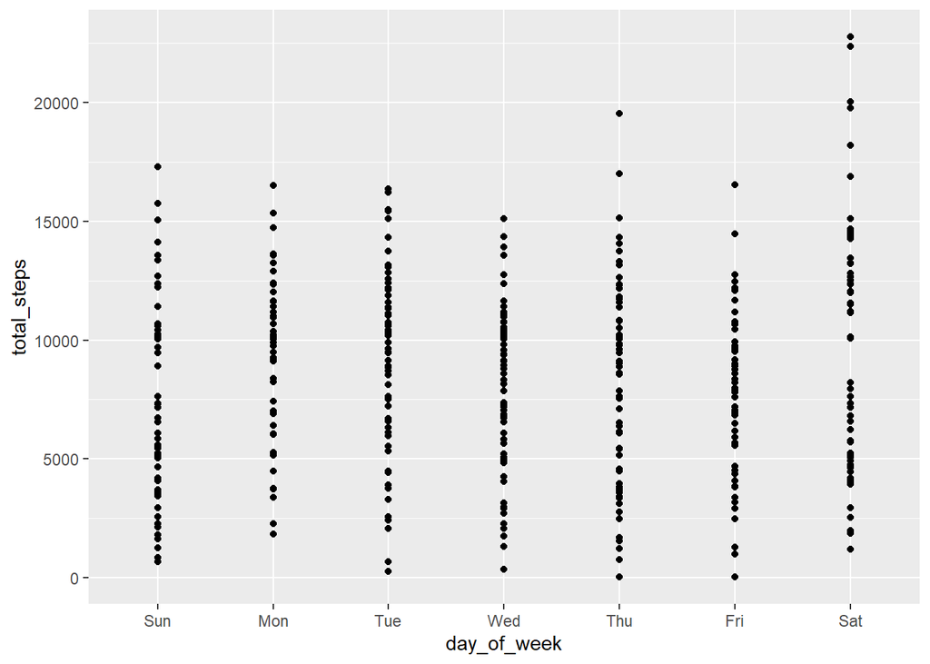

```r
ggplot(data=merged_df) +
  geom_point(mapping = aes(x=day_of_week, y=total_steps))
```

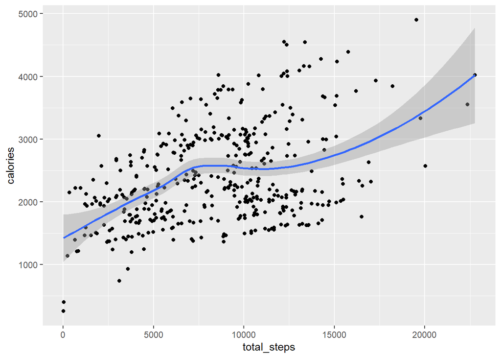

```r
ggplot(data=merged_df) +
  geom_point(mapping = aes(x=total_steps, y=calories)) +
  geom_smooth(mapping = aes(x=total_steps, y=calories))
```